# Reproducible Research: Peer Assessment 1

## Loading and preprocessing the data

```r
library(dplyr)
if (!file.exists("activity.csv")) {
    unzip("activity.zip")
    }
activities <- read.csv("activity.csv",
                       colClasses=c("numeric",
                                    "POSIXct",
                                    "numeric"),
                       stringsAsFactors=FALSE)
```

## What is the mean total number of steps taken per day?

In order to take the first step, the data will be summarizee by date, then over all the intervals.

```r
day_groups <- group_by(activities,
                       date)
bydate <- summarize(day_groups,
                    total=sum(steps,
                              na.rm=TRUE))
```

The resultant histogram of total steps taken per day:

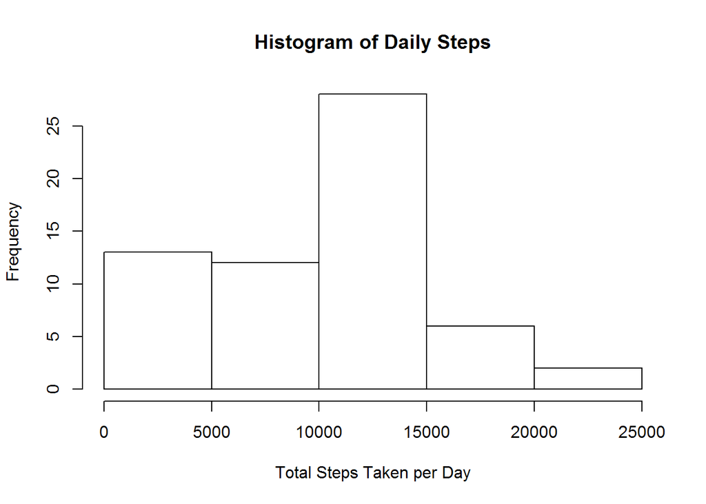

```r
hist(bydate$total,
     main="Histogram of Daily Steps",
     xlab="Total Steps Taken per Day")
```

Mean value and the median value of the total steps taken per day:

```r
mean_steps <- as.integer(mean(bydate$total,
                              na.rm=TRUE))
median_steps <- as.integer(median(bydate$total,
                                  na.rm=TRUE))
```

The mean value of the total steps taken per day is 9354.

The median value of the total steps taken per day is 10395.

## What is the average daily activity pattern?

```r
intervals <- group_by(activities,
                      interval)
byinterval <- summarize(intervals,
                        avg=mean(steps,
                                 na.rm=TRUE))
```

A timeseries will provide insight into most active periods of the day:

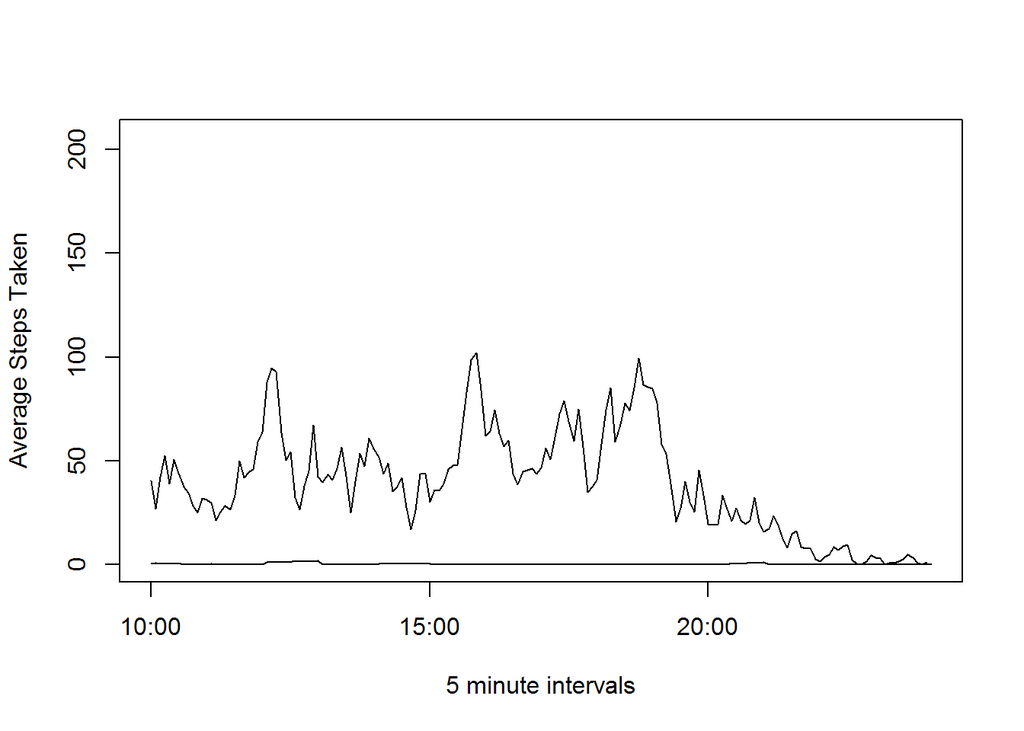

```r
with(byinterval,
     plot(strptime(sprintf("%04s",
                           interval),
                   "%H%M"),
          avg,
          type="l",
          xlab="5 minute intervals",
          ylab="Average Steps Taken"))
```

```r
intvl_max <- sprintf("%04s",
                     byinterval[which.max(byinterval$avg),]$interval)
```

## Imputing missing values

How many step counts are missing:

```r
missing <- count(filter(activities,
                        is.na(steps)))$n
```

The total number of missing values for reported steps is 2304.

```r
imputeStepsIfNA <- function(interval, steps) {
    if (is.na(steps)) {
        as.integer(filter(byinterval,
                          interval==interval)[1,2])
        } else {
            steps
            }
    }
```

Dataset with imputed values:

```r
imputed <- activities
imputed$steps <- mapply(imputeStepsIfNA, imputed$interval, imputed$steps)
```

Summarized data using imputed values.

```r
imputed_day_groups <- group_by(imputed, date)
imputedbydate <- summarize(imputed_day_groups, total=sum(steps, na.rm=TRUE))
```

Histogram of total steps taken per day using imputed values:

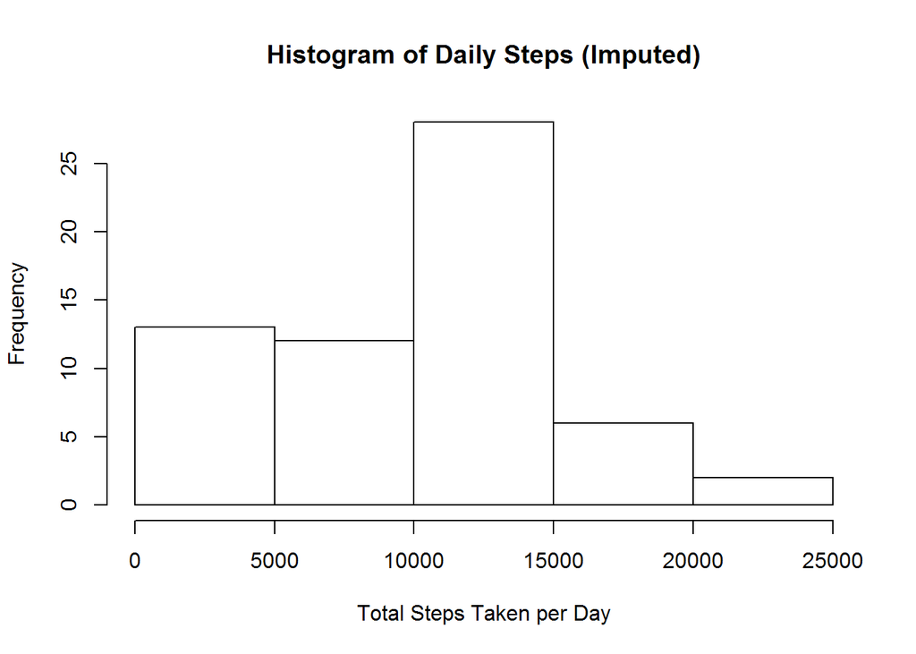

```r
hist(imputedbydate$total,
     main="Histogram of Daily Steps (Imputed)",
     xlab="Total Steps Taken per Day")
```

Calculate both the mean value and the median value of the total steps taken per day with imputed values:

```r
imp_mean_steps <- as.integer(mean(imputedbydate$total))
imp_median_steps <- as.integer(median(imputedbydate$total))
```

The mean value of the total steps taken per day using imputed values is 9354.

The median value of the total steps taken per day using imputed values is 10395.

Considering that these values do not differ from the values determined when ignoring the missing data, we can determine that with this particular approach to imputing values, there is no impact to the mean and median of the steps.

## Are there differences in activity patterns between weekdays and weekends?

Determine the answer to this question by grouping the data differently, add a new column to the dataset that flags an observation as weekday or weekend.

```r
dayType <- function(date) {
    if (weekdays(date) %in% c("Saturday",
                              "Sunday")) {
        "weekend"
        } else {
            "weekday"
            }
    }
imputed$daytype <- factor(mapply(dayType,
                                 imputed$date))
```

Filter by weekday and create a dataframe summarized by the grouping over intervals for all weekdays.

```r
weekday_ints <- group_by(filter(imputed,
                                daytype=='weekday'),
                         interval)
weekday_by_interval <- summarize(weekday_ints,
                                 avg=mean(steps))
```

Filter by weekend and create a dataframe summarized by the grouping over intervals for all weekend days.

```r
weekend_ints <- group_by(filter(imputed,
                                daytype=='weekend'),
                         interval)
weekend_by_interval <- summarize(weekend_ints,
                                 avg=mean(steps))
```

Create two plots, showing a comparison of weekday vs weekend.

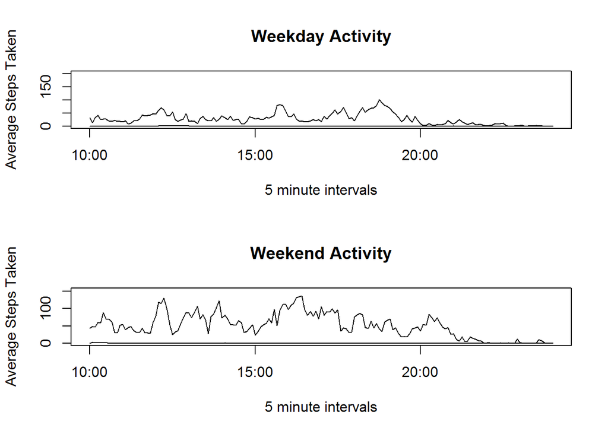

```r
par(mfrow=c(2,1))
with(weekday_by_interval,
     plot(strptime(sprintf("%04s",
                           interval),
                   "%H%M"),
          avg,
          type="l",
          xlab="5 minute intervals",
          ylab="Average Steps Taken",
          main="Weekday Activity"))
with(weekend_by_interval,
     plot(strptime(sprintf("%04s",
                           interval),
                   "%H%M"),
          avg,
          type="l",
          xlab="5 minute intervals",
          ylab="Average Steps Taken",
          main="Weekend Activity"))
```